# Rapport final

Sydol ADOMADE

2024-06-19

## Traitement des données Cezars Mensuelles

La table des données extraites se présente comme suit :

```r
#https://essicolo.github.io/ecologie-mathematique-R/chapitre-temps.html#op%C3%A9rations-sur-les-donn%C3%A9es-temporelles

library(tidyverse)
library(forecast)
library(sf)
library(texreg)
library(tseries)
library(kableExtra)
library(modelsummary)
library(ggplot2)
library(ggthemes)
library(kableExtra)
library(gridExtra)
library(zoo)

cezarTemporel <- st_read("data/faitsTemporelle2015_2023.xlsx") %>%
  st_as_sf(coords = c("Longitude.Gare", "Latitude.Gare" ), crs = 4326, na.fail = F)%>%
  st_transform(2154) %>%
  filter(!(st_is_empty(geometry)))
head(cezarTemporel) %>%
  kable()
```

| Date | Heure | Gare | Nombre.d.actes | geometry |
| --- | --- | --- | --- | --- |
| 08/05/2021 | 23:00:00 | St-Cyr | 8 | POINT (631889 6855793) |
| 30/01/2021 | 18:05:00 | Le Bras-de-fer | 8 | POINT (659522.2 6836041) |
| 30/10/2023 | 00:45:00 | Rambouillet | 7 | POINT (613905.1 6838762) |
| 01/05/2021 | 20:25:00 | Paris-Nord | 7 | POINT (652782.3 6864817) |
| 25/09/2022 | 15:20:00 | Cannes | 7 | POINT (1024709 6281036) |
| 21/08/2022 | 10:50:00 | Bordeaux-St-Jean | 6 | POINT (419015.5 6420413) |

## Traitement des données Cezar Mensuelles

Notre extraction des données Cezar contient le nombre de faits enregistrés chaque jour pour chaque gare. L’objectif est d’utiliser cette série chronologique des faits de délinquance pour créer un modèle de la famille des modèles ARMA, afin d’établir des prévisions sur la délinquance en gare.

Dans cette première partie, nous allons étudier la série à une échelle temporelle mensuelle, ce qui est le plus pertinent pour des analyses futures en raison du délai moyen de consolidation de la base de données d’un mois.

Les données sont regroupées par mois et les éventuelles données erronées sont supprimées. Ensuite, le champ de date est converti en format POSIXct (format de date en R) et classé par ordre chronologique. Elles sont ensuite converties en objet de type time series pour examiner la distribution et les différents graphiques d’autocorrélation.

```r
colnames(cezarTemporel) <- c("Date", "Heure", "Gare", "NombredActes", "geometry")

# Convertion des dates en Posixct
cezarTemporel$dateHeure <- as.POSIXct(strptime(paste(gsub("/","-",cezarTemporel$Date), cezarTemporel$Heure),
                                               "%d-%m-%Y %H:%M:%S", tz = "GMT"),
                                      tryFormats = c("%d-%m-%Y %H:%M:%OS",
                                                     "%d-%m-%Y %H:%M:%OS",
                                                     "%d-%m-%Y %H:%M",
                                                     "%d-%m-%Y %H:%M",
                                                     "%d-%m-%Y",
                                                     "%d-%m-%Y"),
                                      tz = "GMT",
                                      optional = FALSE )

#trier selon la chronologie temporelle.
cezarTemporel <- cezarTemporel%>%
  arrange(dateHeure)

# Création de champs specifiques aux dates
cezarTemporel$mois <- month(cezarTemporel$dateHeure)
cezarTemporel$jour <- day(cezarTemporel$dateHeure)
cezarTemporel$heure <- hour(cezarTemporel$dateHeure)
cezarTemporel$annee <- year(cezarTemporel$dateHeure)
cezarTemporel$YearMonth <- ymd(paste0(cezarTemporel$annee, "-", cezarTemporel$mois, "-01"))

# Isolation des données de 2024
cezartemporel2024 <- cezarTemporel%>%
  filter(
    annee > 2022
    )%>%
  mutate(
    YearMonth = ymd(paste0(annee, "-", mois, "-01"))
  ) %>%
  group_by(YearMonth) %>%
  summarise(
    NombredActes = sum(NombredActes)
  )

# Suppression d'eventuelles données manquantes, des années 2019 et 2020 ainsi que toutes les données de 2024 qui sont isolées pour verifier la pertinace des prevs

cezarTemporel <- cezarTemporel %>%
  filter(!is.na(NombredActes))%>%
  filter(
    !(annee %in% c(2020,2019))
    )
# Grouper les données par mois pour chaque année
cezarTemporelMensuel <- cezarTemporel %>%
  group_by(YearMonth) %>%
  summarise(
    NombredActes = sum(NombredActes)
  )

# Conversion des données en objet TS.
ts_cezarMensuel <- ts(cezarTemporelMensuel$NombredActes,
                      start = 2015,
                      frequency = 12)
```

## Visualisation de la serie temporelle

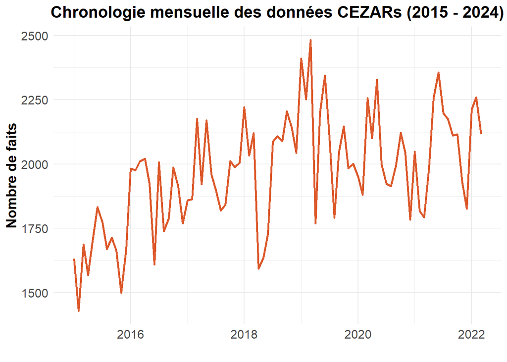

```r
autoplot(ts_cezarMensuel) +
  ggtitle("Chronologie mensuelle des données CEZARs (2015 - 2024)") +
  xlab("") +
  ylab("Nombre de faits") +
  theme_minimal() +  # Utiliser un thème minimal
  theme(
    plot.title = element_text(hjust = 0.5, size = 16, face = "bold"),
    axis.title = element_text(size = 14, face = "bold"),
    axis.text = element_text(size = 12)
  ) +
  geom_line(color = "#DC582A", size = 1)
```

```r
ts_cezarMensuel %>% summary()
```

```
##    Min. 1st Qu.  Median    Mean 3rd Qu.    Max.
##    1430    1806    1987    1967    2116    2483
```

## Decomposition de la serie temporelle

Nous décomposons la série de données Cezar afin de visualiser les éventuelles saisonnalités.

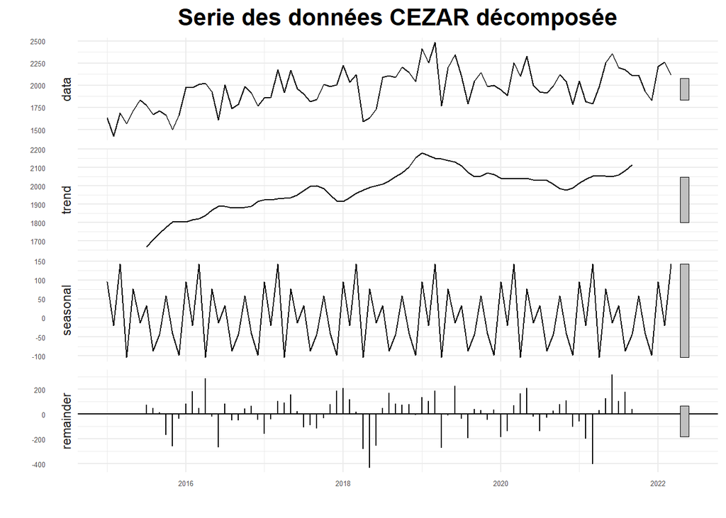

```r
ts_cezarMensuel %>%
  decompose() %>%
  autoplot()+
  ggtitle("Serie des données CEZAR décomposée") +
  xlab("") +
  theme_minimal() +  # Utiliser un thème minimal
  theme(
    plot.title = element_text(hjust = 0.5, size = 16, face = "bold"),
    axis.title = element_text(size = 14, face = "bold"),
    axis.text = element_text(size = 5)
  )
```

Une saisonnalité de 12 mois est perceptible sur ces graphiques.

## Autocorelogramme

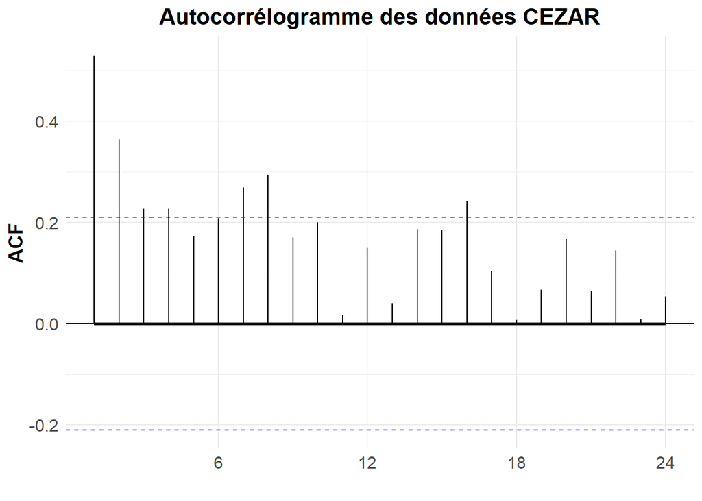

```r
# Graphique d'autocorrelation
ts_cezarMensuel %>%
  ggAcf()+
  ggtitle("Autocorrélogramme des données CEZAR") +
  xlab("") +
  theme_minimal() +  # Utiliser un thème minimal
  theme(
    plot.title = element_text(hjust = 0.5, size = 16, face = "bold"),
    axis.title = element_text(size = 14, face = "bold"),
    axis.text = element_text(size = 12)
  ) +
  geom_line(color = "#000000", size = 1)
```

On observe une corrélation significative jusqu’au 4e lag, avec une significativité beaucoup plus prononcée au 1er lag. La décroissance lente suggère une non-stationnarité de la série.

On effectue un test statistique pour s’en assurer.

## Test de dickey Fuller Augmenté

Effectuons un test de dickey fuller augmenté sur la série pour vérifier mathematiquement sa stationnarité.

```r
# Test de dickey Fuller augmenté.
 adf.test(ts_cezarMensuel, alternative = "stationary")
```

```
##
##  Augmented Dickey-Fuller Test
##
## data:  ts_cezarMensuel
## Dickey-Fuller = -4.0639, Lag order = 4, p-value = 0.01032
## alternative hypothesis: stationary
```

Le test de Dickey-Fuller avancé sur cette série statistique présente une p-value de 0,01, limitant le risque d’erreur à 1%. Pour un seuil de 5%, cela nous permet de rejeter l’hypothèse nulle selon laquelle cette série serait explosive ou non stationnaire.

La série serait donc stationnaire selon ce test. Face à cette controverse, l’utilisation de la série différenciée s’avère être une alternative viable.

## Serie differenciée

La serie differenciée au premier ordre se presente comme suit :

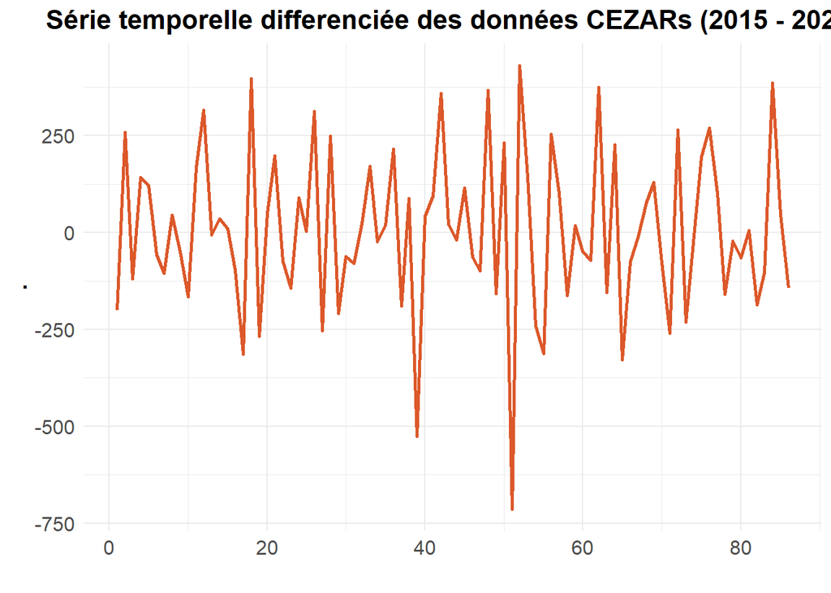

```r
cezarDifferencie <- diff(ts_cezarMensuel)

ts(cezarDifferencie) %>%
  autoplot()+
  ggtitle("Série temporelle differenciée des données CEZARs (2015 - 2024)") +
  xlab("")  +
  theme_minimal() +  # Utiliser un thème minimal
  theme(
    plot.title = element_text(hjust = 0.5, size = 16, face = "bold"),
    axis.title = element_text(size = 14, face = "bold"),
    axis.text = element_text(size = 12)
  ) +
  geom_line(color = "#DC582A", size = 1)
```

## Autocorelogramme de la serie différenciée

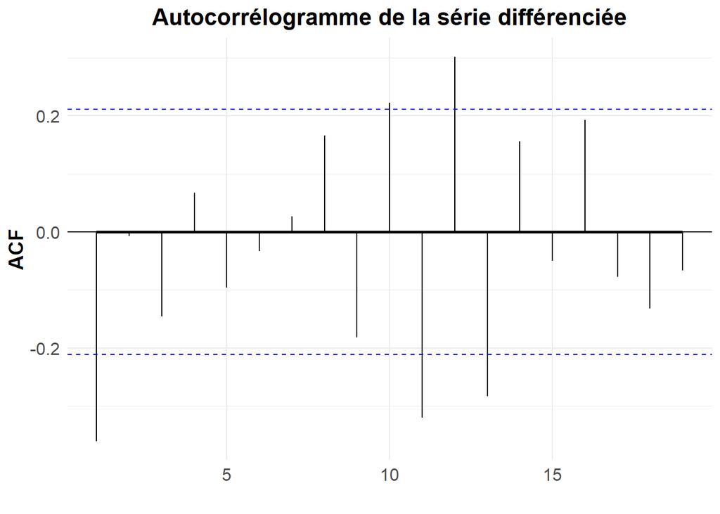

```r
ts(cezarDifferencie) %>%
  ggAcf()+
  ggtitle("Autocorrélogramme de la série différenciée") +
  xlab("") +
  theme_minimal() +  # Utiliser un thème minimal
  theme(
    plot.title = element_text(hjust = 0.5, size = 16, face = "bold"),
    axis.title = element_text(size = 14, face = "bold"),
    axis.text = element_text(size = 12)
  ) +
  geom_line(color = "#000000", size = 1)
```

On observe bel et bien une décroissance rapide de l’ACF, preuve d’une stationnarité de la série différenciée. De plus, la série est négativement corrélée au premier lag. Testons statistiquement cette conclusion.

```r
# Test de dickey Fuller augmenté.
 adf.test(cezarDifferencie, alternative = "stationary")
```

```
##
##  Augmented Dickey-Fuller Test
##
## data:  cezarDifferencie
## Dickey-Fuller = -6.2471, Lag order = 4, p-value = 0.01
## alternative hypothesis: stationary
```

Avec une p-valeur de 0,01, l’hypothèse de non-stationnarité peut être rejetée pour un seuil d’erreur de 5%.

Les diverses analyses allant dans le même sens, on peut confirmer que la série est stationnaire.

**Une différenciation d’ordre 1 devra donc être intégrée dans le modèle.**

À la visualisation de l’autocorrélogramme, la corrélation est forte et négative au premier lag. Une composante MA d’ordre 1 devra donc être incluse dans le modèle.

## Autocorrelogramme partiel de la serie differenciée

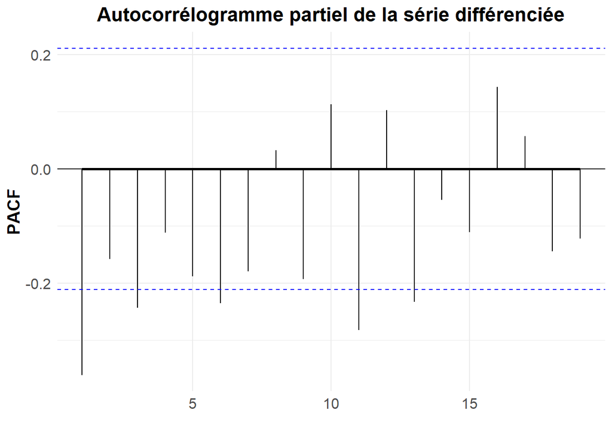

```r
ts(cezarDifferencie) %>%
  ggPacf()+
  ggtitle("Autocorrélogramme partiel de la série différenciée") +
  xlab("") +
  theme_minimal() +  # Utiliser un thème minimal
  theme(
    plot.title = element_text(hjust = 0.5, size = 16, face = "bold"),
    axis.title = element_text(size = 14, face = "bold"),
    axis.text = element_text(size = 12)
  ) +
  geom_line(color = "#000000", size = 1)
```

La décroissance est brusque avec une forte corrélation au premier lag. Une rupture dans la significativité est observable au deuxième lag avant de redevenir significative au troisième. Par prudence, seule la corrélation au premier lag sera prise en compte. La composante AR sera donc d’ordre 1.

## Conception est test du model

La saisonnalité de 12 mois observée plus tôt sera prise en compte dans le modèle avec les mêmes paramètres AR et MA.

Le modèle ‘model1’ est basé sur les données brutes, tandis que le modèle ‘modelLog’ est basé sur une transformation logarithmique de la série.

#### Preparation des fonctions de test

```r
# Fonction de test de significativité des parametres
t_stat = function(modarima, decim = 6) {
  if(!is(modarima, "Arima"))
    stop("modarima may be an Arima object from package forecast")
  t.stat <- modarima$coef[modarima$mask == TRUE] / sqrt(diag(modarima$var.coef))
  p.val <- rep(0, length(t.stat))
  p.val[t.stat < 0] <- 2 * pnorm(t.stat[t.stat < 0])
  p.val[t.stat > 0] <- 2 * (1 - pnorm(t.stat[t.stat > 0]))
  round(rbind(t.stat, p.val), digits = decim)
}

# Fonction de test de residus
Box.test.2 <- function(x, nlag, type = c("Box-Pierce", "Ljung-Box"), fitdf = 0, decim=8) {
 Box.test.inv = function(lag1, x, type = c("Box-Pierce", "Ljung-Box"), fitdf = 0) {
   stats::Box.test(x, lag1, type = c("Box-Pierce", "Ljung-Box"), fitdf = fitdf)$p.value
 }
 x <- as.vector(x)
 nlag <- as.matrix(nlag)
 aa <- round(apply(nlag, 1, Box.test.inv, x), digits = decim)
 bb <- cbind(as.integer(nlag), as.matrix(aa))
 colnames(bb) <- c("Retard", "p-value")
 bb
}
```

### Model1

```r
model1 <- Arima(ts_cezarMensuel,order=c(1,1,1),list(order=c(1,0,1), period = 12),include.mean=FALSE,method="CSS-ML", include.drift = FALSE)

 model1 %>%
   summary()
```

```
## Series: ts_cezarMensuel
## ARIMA(1,1,1)(1,0,1)[12]
##
## Coefficients:
##          ar1      ma1    sar1     sma1
##       0.4371  -0.9130  0.9871  -0.9114
## s.e.  0.1216   0.0524  0.1112   0.3848
##
## sigma^2 = 27231:  log likelihood = -563.59
## AIC=1137.18   AICc=1137.93   BIC=1149.45
##
## Training set error measures:
##                    ME     RMSE      MAE       MPE     MAPE      MASE       ACF1
## Training set 14.30263 160.2073 128.9786 0.2046812 6.617734 0.6051165 0.01688704
```

#### Test de significativité des parametres.

##### test de student

```r
model1 %>%
  t_stat() %>%
  as.data.frame()
```

```
##             ar1       ma1     sar1      sma1
## t.stat 3.593530 -17.41681 8.875386 -2.368486
## p.val  0.000326   0.00000 0.000000  0.017861
```

Tous les paramètres sont visiblement significatifs.

##### test de Ljung-Box et graphiques des residus.

```r
Box.test.2(model1$residuals,nlag=c(1,2,3,6,12,18,24,30,36),type="Ljung-Box",decim=5)
```

```
##       Retard p-value
##  [1,]      1 0.87484
##  [2,]      2 0.85206
##  [3,]      3 0.86425
##  [4,]      6 0.93325
##  [5,]     12 0.90714
##  [6,]     18 0.85204
##  [7,]     24 0.89331
##  [8,]     30 0.91496
##  [9,]     36 0.90623
```

Les p-valeurs relativement élevées nous permettent de confirmer l’hypothèse nulle d’une distribution aléatoire des résidus.

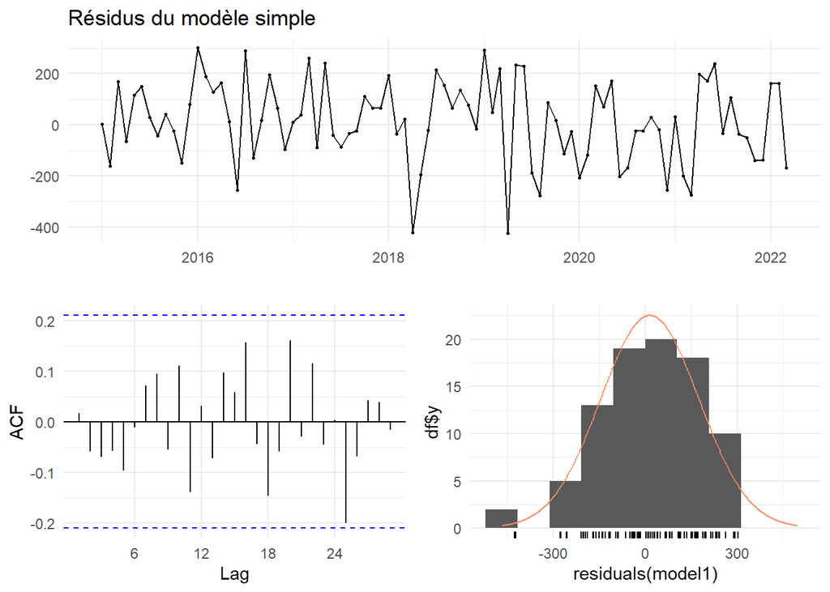

```r
ggtsdisplay(residuals(model1), plot.type = "histogram", theme = theme_minimal(), main = "Résidus du modèle simple")
```

Les résidus suivent une distribution normale et ne présentent aucune corrélation, ce qui traduit une modélisation quasi totale de toutes les patterns présentes dans les données.

À la suite de tout ceci, on peut affirmer que les résidus sont des bruits blancs.

### ModelLog

```r
logTsCezar <- log(ts_cezarMensuel)

modelLog <- Arima(logTsCezar,order=c(1,1,1),seasonal = list(order=c(1,0,1), period = 12),include.mean=FALSE,method="CSS-ML", include.drift = FALSE)

modelLog %>%
  summary()
```

```
## Series: logTsCezar
## ARIMA(1,1,1)(1,0,1)[12]
##
## Coefficients:
##          ar1     ma1    sar1     sma1
##       0.4454  -0.911  0.9940  -0.9403
## s.e.  0.1216   0.053  0.0593   0.2948
##
## sigma^2 = 0.007044:  log likelihood = 87.9
## AIC=-165.8   AICc=-165.05   BIC=-153.53
##
## Training set error measures:
##                       ME       RMSE        MAE        MPE      MAPE      MASE
## Training set 0.007358566 0.08148007 0.06577247 0.08823086 0.8686709 0.6015411
##                    ACF1
## Training set 0.02324078
```

#### Test de significativité des parametres.

##### test de student

```r
modelLog %>%
  t_stat() %>%
  as.data.frame()
```

```
##             ar1       ma1     sar1      sma1
## t.stat 3.662397 -17.18991 16.77645 -3.189208
## p.val  0.000250   0.00000  0.00000  0.001427
```

Tous les paramètres sont visiblement significatifs.

##### test de Ljung-Box et graphiques des residus.

```r
Box.test.2(modelLog$residuals,nlag=c(1,2,3,6,12,18,24,30,36),type="Ljung-Box",decim=5)
```

```
##       Retard p-value
##  [1,]      1 0.82838
##  [2,]      2 0.79135
##  [3,]      3 0.84922
##  [4,]      6 0.87849
##  [5,]     12 0.87336
##  [6,]     18 0.81896
##  [7,]     24 0.87214
##  [8,]     30 0.90686
##  [9,]     36 0.90113
```

Les p-valeurs relativement élevées nous permettent de confirmer l’hypothèse nulle d’une distribution aléatoire des résidus.

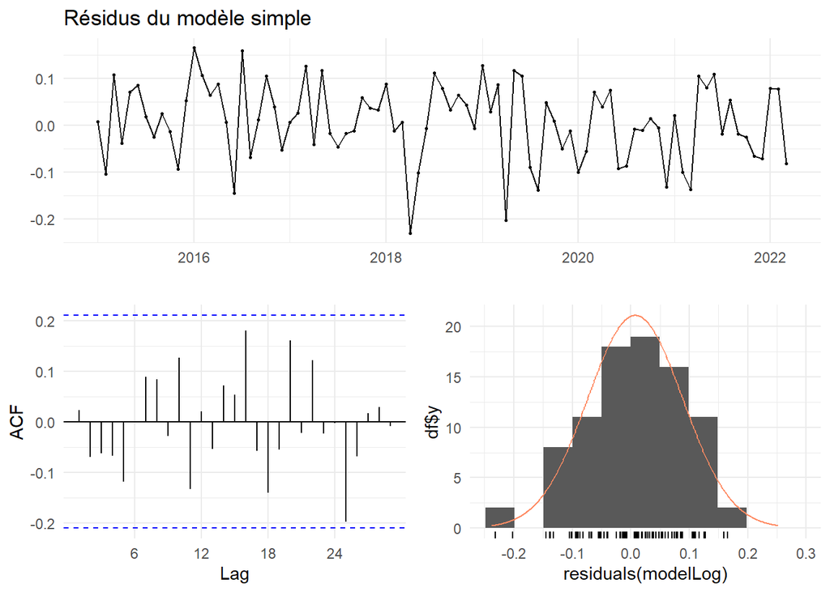

```r
ggtsdisplay(residuals(modelLog), plot.type = "histogram", theme = theme_minimal(), main = "Résidus du modèle simple")
```

Les résidus suivent une distribution normale et ne présentent aucune corrélation, ce qui traduit une modélisation quasi totale de toutes les patterns présentes dans les données.

À la suite de tout ceci, on peut affirmer que les résidus sont des bruits blancs.

**En conclusion générale, les deux modèles sont viables.**

## Tests de prévisions

```r
#Isolement des valeurs de test
cezartemporel2024 <- ts(cezartemporel2024$NombredActes,start=c(2021,1),frequency=12)
```

### Model1

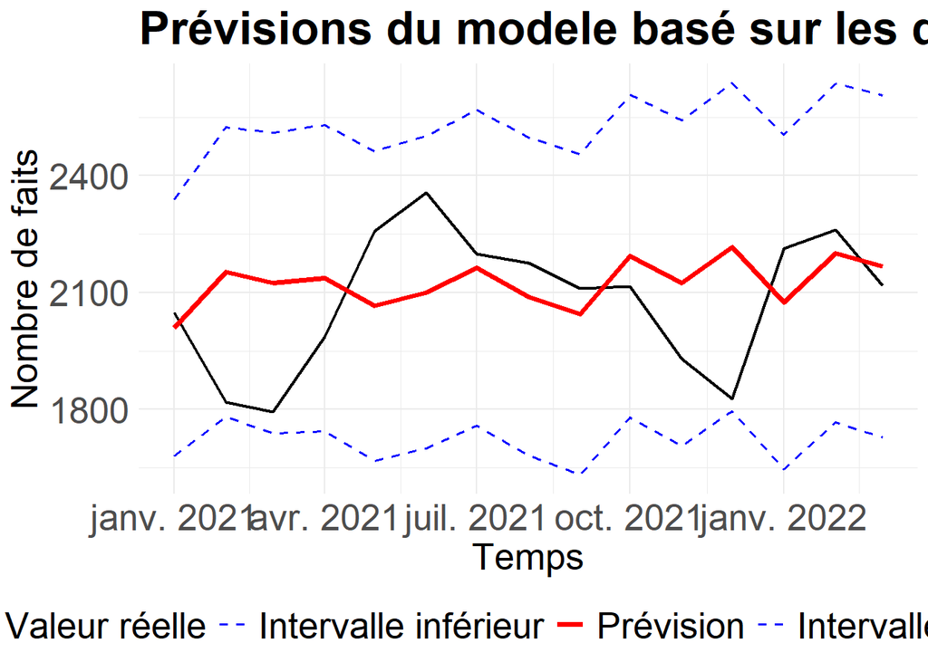

```r
pred <- forecast(model1,h=15,level=95)

pred_m <- ts(pred$mean,start=c(2021,1),frequency=12)

pred_l <- ts(pred$lower,start=c(2021,1),frequency=12)

pred_u <- ts(pred$upper,start=c(2021,1),frequency=12)

# Conversion des séries temporelles en data frame
time_index <- as.yearmon(time(cezartemporel2024)) # Utilisation de as.yearmon pour obtenir les dates
data <- data.frame(
  time = as.Date(as.yearmon(time_index)),
  observed = as.numeric(cezartemporel2024),
  pred_m = as.numeric(pred_m),
  pred_l = as.numeric(pred_l),
  pred_u = as.numeric(pred_u)
)

# Transformation des données en format long pour ggplot
data_long <- data %>%
  pivot_longer(cols = -time, names_to = "variable", values_to = "value")

# Création du graphique avec ggplot2
ggplot(data_long, aes(x = time, y = value, color = variable, linetype = variable, size = variable)) +
  geom_line() +
  scale_color_manual(
    values = c("observed" = "black", "pred_m" = "red", "pred_l" = "blue", "pred_u" = "blue"),
    labels = c("observed" = "Valeur réelle", "pred_m" = "Prévision", "pred_l" = "Intervalle inférieur", "pred_u" = "Intervalle supérieur")
  ) +
  scale_linetype_manual(
    values = c("observed" = "solid", "pred_m" = "solid", "pred_l" = "dashed", "pred_u" = "dashed"),
    labels = c("observed" = "Valeur réelle", "pred_m" = "Prévision", "pred_l" = "Intervalle inférieur", "pred_u" = "Intervalle supérieur")
  ) +
  scale_size_manual(
    values = c("observed" = .8, "pred_m" = 1.4, "pred_l" = 0.6, "pred_u" = 0.6),
    labels = c("observed" = "Valeur réelle", "pred_m" = "Prévision", "pred_l" = "Intervalle inférieur", "pred_u" = "Intervalle supérieur")
  ) +
  labs(title = "Prévisions du modele basé sur les données brutes",
       x = "Temps",
       y = "Nombre de faits",
       color = "",
       linetype = "",
       size = "") +
  theme_minimal() +
  theme(
    legend.position = "bottom",
    plot.title = element_text(size = 25, face = "bold"),
    axis.title.x = element_text(size = 20),
    axis.title.y = element_text(size = 20),
    axis.text.x = element_text(size = 20),
    axis.text.y = element_text(size = 20),
    legend.title = element_text(size = 20),
    legend.text = element_text(size = 20))
```

```r
pred_simple <- pred_m
predtable <- data.frame(as.vector(cezartemporel2024), as.vector(pred_simple), as.vector(pred_simple))

colnames(predtable) <- c("Valeurs réelles", "Prev basiques", "Prev log")

predtable$diffBase <- predtable$`Prev basiques`- predtable$`Valeurs réelles`

predtable$diffLog <- predtable$`Prev log` - predtable$`Valeurs réelles`

predtable %>%
  kable()
```

| Valeurs réelles | Prev basiques | Prev log | diffBase | diffLog |
| --- | --- | --- | --- | --- |
| 2049 | 2009.477 | 2009.477 | -39.52302 | -39.52302 |
| 1818 | 2152.907 | 2152.907 | 334.90728 | 334.90728 |
| 1793 | 2124.321 | 2124.321 | 331.32083 | 331.32083 |
| 1987 | 2136.756 | 2136.756 | 149.75557 | 149.75557 |
| 2257 | 2065.901 | 2065.901 | -191.09872 | -191.09872 |
| 2357 | 2100.502 | 2100.502 | -256.49788 | -256.49788 |
| 2198 | 2163.916 | 2163.916 | -34.08443 | -34.08443 |
| 2176 | 2089.577 | 2089.577 | -86.42306 | -86.42306 |
| 2111 | 2044.808 | 2044.808 | -66.19213 | -66.19213 |
| 2116 | 2193.537 | 2193.537 | 77.53739 | 77.53739 |
| 1930 | 2124.387 | 2124.387 | 194.38688 | 194.38688 |
| 1827 | 2216.694 | 2216.694 | 389.69419 | 389.69419 |
| 2213 | 2075.250 | 2075.250 | -137.75009 | -137.75009 |
| 2260 | 2201.387 | 2201.387 | -58.61330 | -58.61330 |
| 2117 | 2166.422 | 2166.422 | 49.42231 | 49.42231 |

### ModelLog

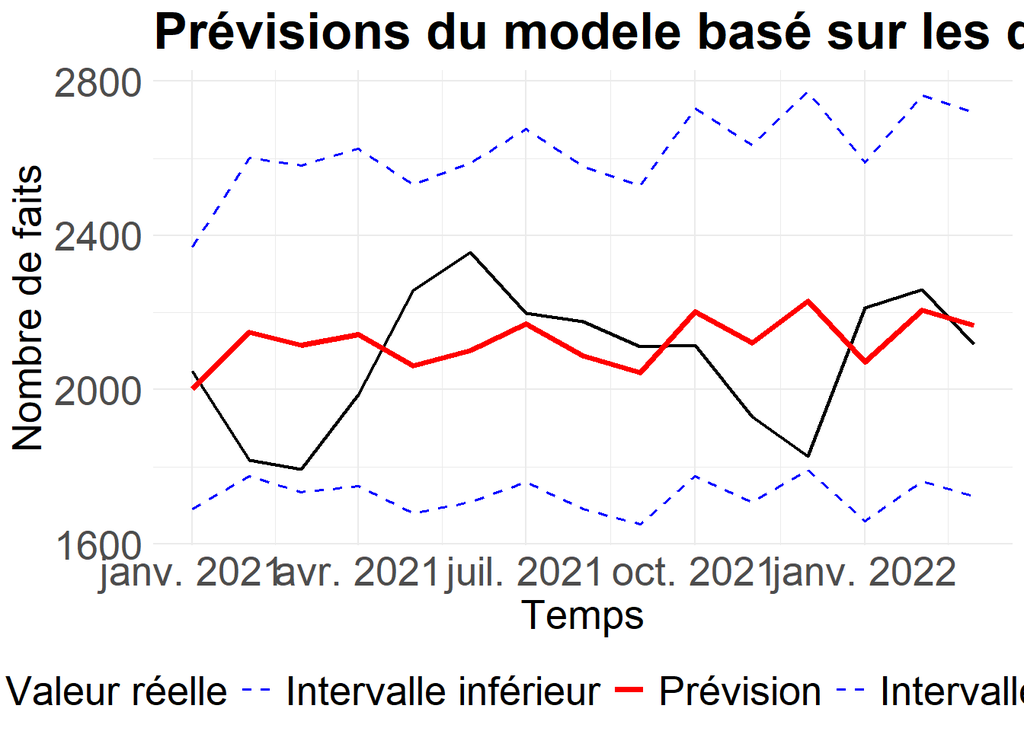

```r
pred <- forecast(modelLog,h=15,level=95)

pred_m <- ts(exp(pred$mean),start=c(2021,1),frequency=12)

pred_l <- ts(exp(pred$lower),start=c(2021,1),frequency=12)

pred_u <- ts(exp(pred$upper),start=c(2021,1),frequency=12)
# Conversion des séries temporelles en data frame
time_index <- as.yearmon(time(cezartemporel2024)) # Utilisation de as.yearmon pour obtenir les dates
data <- data.frame(
  time = as.Date(as.yearmon(time_index)),
  observed = as.numeric(cezartemporel2024),
  pred_m = as.numeric(pred_m),
  pred_l = as.numeric(pred_l),
  pred_u = as.numeric(pred_u)
)

# Transformation des données en format long pour ggplot
data_long <- data %>%
  pivot_longer(cols = -time, names_to = "variable", values_to = "value")

# Création du graphique avec ggplot2
ggplot(data_long, aes(x = time, y = value, color = variable, linetype = variable, size = variable)) +
  geom_line() +
  scale_color_manual(
    values = c("observed" = "black", "pred_m" = "red", "pred_l" = "blue", "pred_u" = "blue"),
    labels = c("observed" = "Valeur réelle", "pred_m" = "Prévision", "pred_l" = "Intervalle inférieur", "pred_u" = "Intervalle supérieur")
  ) +
  scale_linetype_manual(
    values = c("observed" = "solid", "pred_m" = "solid", "pred_l" = "dashed", "pred_u" = "dashed"),
    labels = c("observed" = "Valeur réelle", "pred_m" = "Prévision", "pred_l" = "Intervalle inférieur", "pred_u" = "Intervalle supérieur")
  ) +
  scale_size_manual(
    values = c("observed" = .8, "pred_m" = 1.4, "pred_l" = 0.6, "pred_u" = 0.6),
    labels = c("observed" = "Valeur réelle", "pred_m" = "Prévision", "pred_l" = "Intervalle inférieur", "pred_u" = "Intervalle supérieur")
  ) +
  labs(title = "Prévisions du modele basé sur les données brutes",
       x = "Temps",
       y = "Nombre de faits",
       color = "",
       linetype = "",
       size = "") +
  theme_minimal() +
  theme(
    legend.position = "bottom",
    plot.title = element_text(size = 25, face = "bold"),
    axis.title.x = element_text(size = 20),
    axis.title.y = element_text(size = 20),
    axis.text.x = element_text(size = 20),
    axis.text.y = element_text(size = 20),
    legend.title = element_text(size = 20),
    legend.text = element_text(size = 20))
```

```r
pred_log <- pred_m
predtable <- data.frame(as.vector(cezartemporel2024), as.vector(pred_simple), as.vector(pred_log))

colnames(predtable) <- c("Valeurs réelles", "Prev basiques", "Prev log")

predtable$diffBase <- predtable$`Prev basiques`- predtable$`Valeurs réelles`

predtable$diffLog <- predtable$`Prev log` - predtable$`Valeurs réelles`

predtable %>%
  kable()
```

| Valeurs réelles | Prev basiques | Prev log | diffBase | diffLog |
| --- | --- | --- | --- | --- |
| 2049 | 2009.477 | 2002.131 | -39.52302 | -46.86875 |
| 1818 | 2152.907 | 2148.766 | 334.90728 | 330.76640 |
| 1793 | 2124.321 | 2116.428 | 331.32083 | 323.42817 |
| 1987 | 2136.756 | 2143.153 | 149.75557 | 156.15317 |
| 2257 | 2065.901 | 2062.055 | -191.09872 | -194.94495 |
| 2357 | 2100.502 | 2102.071 | -256.49788 | -254.92882 |
| 2198 | 2163.916 | 2169.841 | -34.08443 | -28.15910 |
| 2176 | 2089.577 | 2087.884 | -86.42306 | -88.11644 |
| 2111 | 2044.808 | 2044.649 | -66.19213 | -66.35066 |
| 2116 | 2193.537 | 2201.738 | 77.53739 | 85.73774 |
| 1930 | 2124.387 | 2121.779 | 194.38688 | 191.77876 |
| 1827 | 2216.694 | 2229.314 | 389.69419 | 402.31388 |
| 2213 | 2075.250 | 2072.801 | -137.75009 | -140.19945 |
| 2260 | 2201.387 | 2206.562 | -58.61330 | -53.43795 |
| 2117 | 2166.422 | 2166.086 | 49.42231 | 49.08627 |

Pour les deux models les ecarts de prédictions sont acceptables.

## Ajustement des prévisions

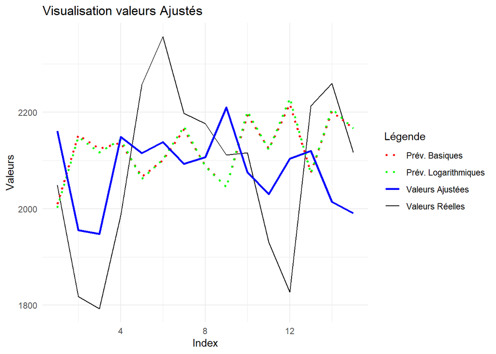

```r
predtable <- data.frame(as.vector(cezartemporel2024), as.vector(pred_simple), as.vector(pred_log))

colnames(predtable) <- c("ValeursReelles", "PrevBasiques", "prevLogarithmiques")
# Modèle de régression linéaire
modajustement <- lm(data = predtable, ValeursReelles ~ PrevBasiques + prevLogarithmiques)

# Prédiction des valeurs ajustées et calcul de la différence ajustée
predtable$valeurAjuste <- predict(modajustement, newdata = predtable)
predtable$diffAjusted <- predtable$valeurAjuste - predtable$ValeursReelles


ggplot(predtable, aes(x = seq_along(ValeursReelles))) +
  geom_line(aes(y = ValeursReelles, color = "Valeurs Réelles"), size = .4) +
  geom_line(aes(y = PrevBasiques, color = "Prév. Basiques"), linetype = "dotted", size = 1) +
  geom_line(aes(y = prevLogarithmiques, color = "Prév. Logarithmiques"), linetype = "dotted", size = 1)  +
  geom_line(aes(y = valeurAjuste, color = "Valeurs Ajustées"), linetype = "solid", size = 1) +
  labs(title = "Visualisation valeurs Ajustés",
       x = "Index",
       y = "Valeurs",
       color = "Légende") +
  theme_minimal() +
  scale_color_manual(values = c("Valeurs Réelles" = "black", "Prév. Basiques" = "red", "Prév. Logarithmiques" = "green", "Valeurs Ajustées" = "blue"))
```